# Report of Corona in West Bank and Gaza

Manuka Perera

2022-10-08

## West Bank and Gaza

### **West Bank**

West Bank ,area of the former British-mandated but occupied from 1967 by Israel. Now it’s a state of Palestine, Israel. Total area of West Bank is 5,655km^2. Palestinian Arabic, Israeli Hebrew are the main languages used in the region. Islam, Judaism, Christianity, Samaritanism are the main reliogions.New shekel(ILS),Jordanian dinar(JOD) are use as currency.

### **Gaza**

Gaza,is a Palestinian city in the Gaza Strip, with a population of 590,481, making it the largest city in the State of Palestine. Total area of West Bank is 45 km^2.The major agricultural products are strawberries, citrus, dates, olives, flowers, and various vegetables.Small-scale industries include the production of plastics, construction materials, textiles, furniture, pottery, tiles, copperware, and carpets.Gaza’s cuisine is characterized by its generous use of spices and chillies.

### **Geographical Location of West Bank and Gaza**

[interactive chart not shown]

### **Climate variation in West Bank and Gaza**

The climate in the West Bank is mostly Mediterranean, slightly cooler at elevated areas compared with the shoreline, west to the area. In the east, the West Bank includes the Judean Desert and the shoreline of the Dead Sea – both with dry and hot climate.

Gaza has a hot semi-arid climate with Mediterranean characteristics, featuring mild rainy winters and dry hot summers.Spring arrives around March or April and the hottest month is August. The coolest month is January.

### **Corona status in West Bank and Gaza**

West bank and Gaza has 702,804 confirmed cases and 5,707 deaths according to a research by John Hopkins, University of Medicine. As for the Vaccine tracker 3,741,181 doses administered and 2,010,433 people received at least 1 dose. It is 39.41% percentage.

### **Actions took by the government to reduce Corona**

By 22 March, the following guidelines were in place, * Closure of all schools, universities and public parks for 30 days (from 5 March - 5 April) * Closure of all borders (movement of goods is allowed) * Government quarantine (14 days) and testing for all incoming travellers (from Ben Gurion airport) * No movement between West Bank governorates * Palestinian laborers who travel to Israel for work are asked not to move between State of Palestine and Israel * No movement within all urban areas (except for exceptional circumstances), with all citizens requested to remain with their homes for 14 days (from March 22) * Closure of all stores, public institutions and government offices, except for essential providers (pharmacies and food) and the Ministries of Health, Finance and Interior (for 14 days from 22 March) * All citizens are asked to stay at home, except for essential activities and emergencies (for 14 days from 22 March).

## Exploratory Data Analysis

#### **Summary of West Bank and Gaza**

```
      date              province           country               lat
 Min.   :2020-01-22   Length:2652        Length:2652        Min.   :31.95
 1st Qu.:2020-08-29   Class :character   Class :character   1st Qu.:31.95
 Median :2021-04-07   Mode  :character   Mode  :character   Median :31.95
 Mean   :2021-04-07                                         Mean   :31.95
 3rd Qu.:2021-11-14                                         3rd Qu.:31.95
 Max.   :2022-06-23                                         Max.   :31.95

      long           type               cases              uid
 Min.   :35.23   Length:2652        Min.   :    0.0   Min.   :275
 1st Qu.:35.23   Class :character   1st Qu.:    0.0   1st Qu.:275
 Median :35.23   Mode  :character   Median :    5.0   Median :275
 Mean   :35.23                      Mean   :  368.6   Mean   :275
 3rd Qu.:35.23                      3rd Qu.:  370.0   3rd Qu.:275
 Max.   :35.23                      Max.   :30356.0   Max.   :275
                                    NA's   :3
     iso2               iso3               code3     combined_key
 Length:2652        Length:2652        Min.   :275   Length:2652
 Class :character   Class :character   1st Qu.:275   Class :character
 Mode  :character   Mode  :character   Median :275   Mode  :character
                                       Mean   :275
                                       3rd Qu.:275
                                       Max.   :275

   population      continent_name     continent_code
 Min.   :5101416   Length:2652        Length:2652
 1st Qu.:5101416   Class :character   Class :character
 Median :5101416   Mode  :character   Mode  :character
 Mean   :5101416
 3rd Qu.:5101416
 Max.   :5101416
```

#### **Total number of Death cases reported in West Bank and Gaza**

```
[1] 5660
```

#### **Graphical Representation of deaths over time in West Bank and Gaza**

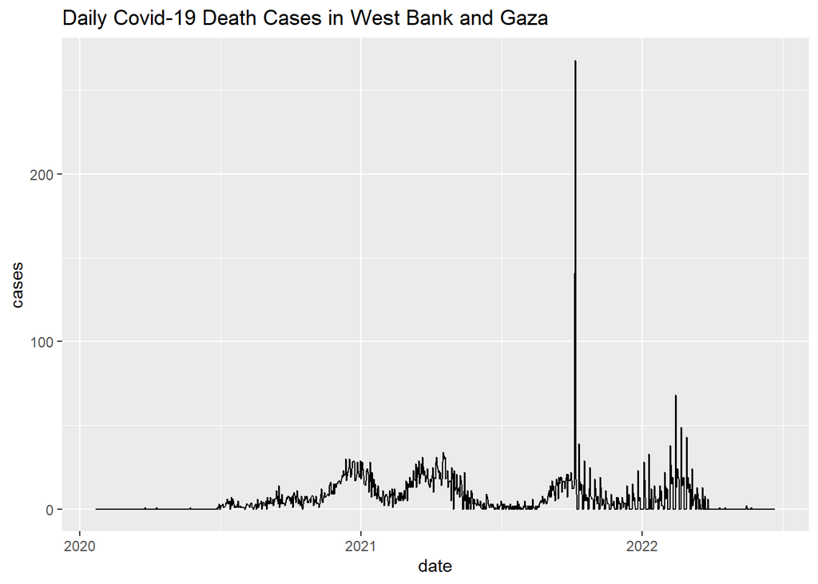

Figure 1

#### **Histogram of deaths in West Bank and Gaza**

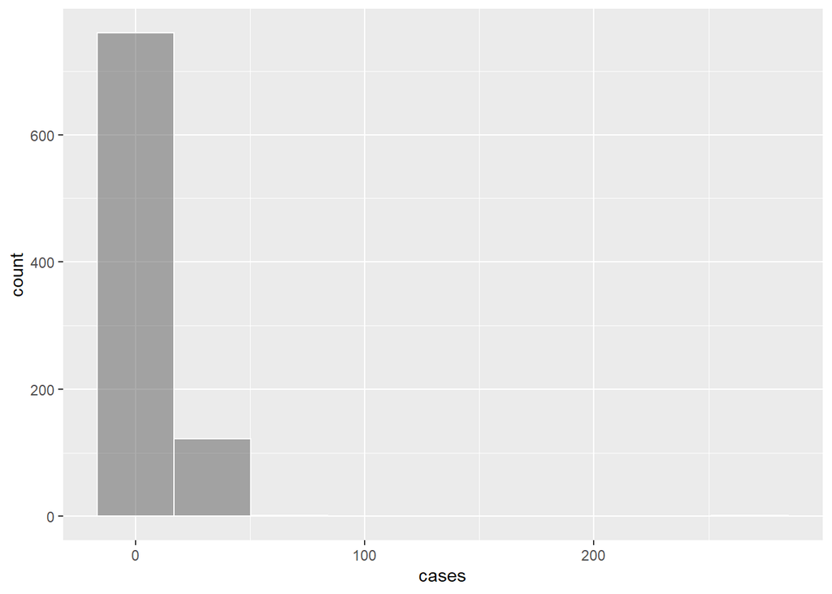

Figure 2

#### **Total number of Confirmed cases reported in West Bank and Gaza**

```
[1] 658503
```

#### **Graphical Representation of confirmed cases over time in West Bank and Gaza**

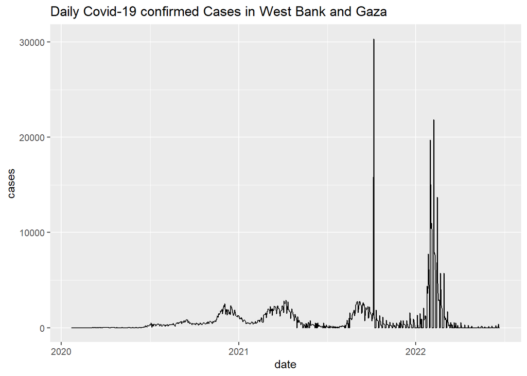

Figure 3

#### **Histogram of confirmed cases in West Bank and Gaza**

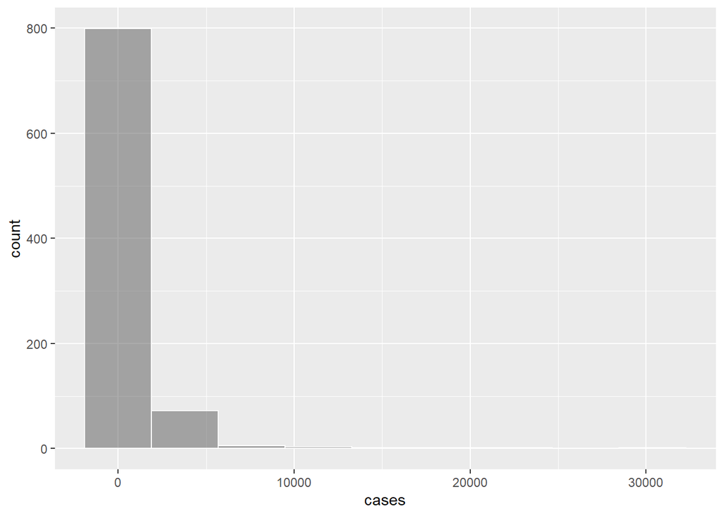

Figure 4

#### **Total number of Recovered cases reported in West Bank and Gaza**

```
[1] 312359.5
```

#### **Graphical Representation of recovered cases over time in West Bank and Gaza**

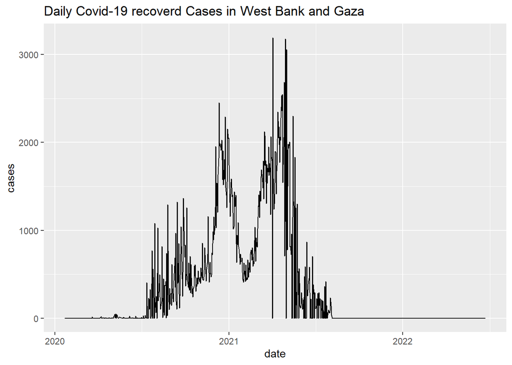

Figure 5

#### **Histogram of recovered cases in West Bank and Gaza**

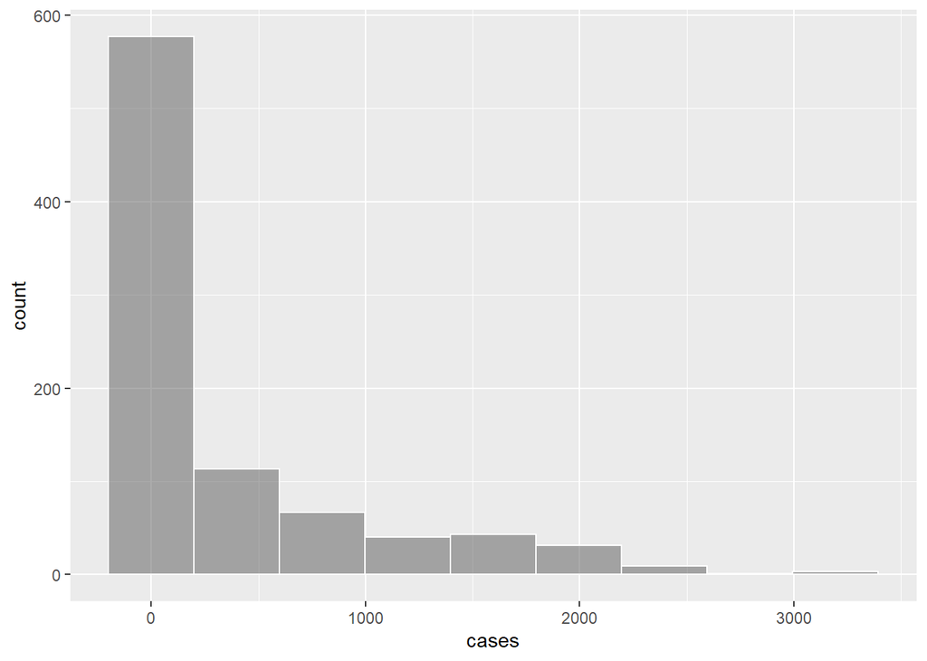

Figure 6

#### **Total number of Active cases reported in West Bank and Gaza**

```
[1] 340483.5
```

#### **Graphical Representation of cumulative active cases over time in West Bank and Gaza**

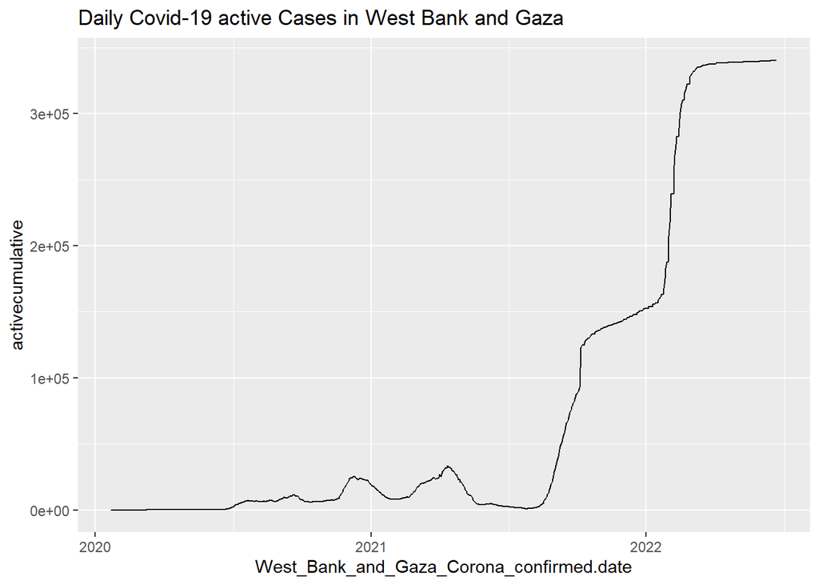

Figure 7

| Type | Total |
| --- | --- |
| Confirmed | 658503.0 |
| Death | 5660.0 |
| Recovered | 312359.5 |
| Active | 340483.5 |

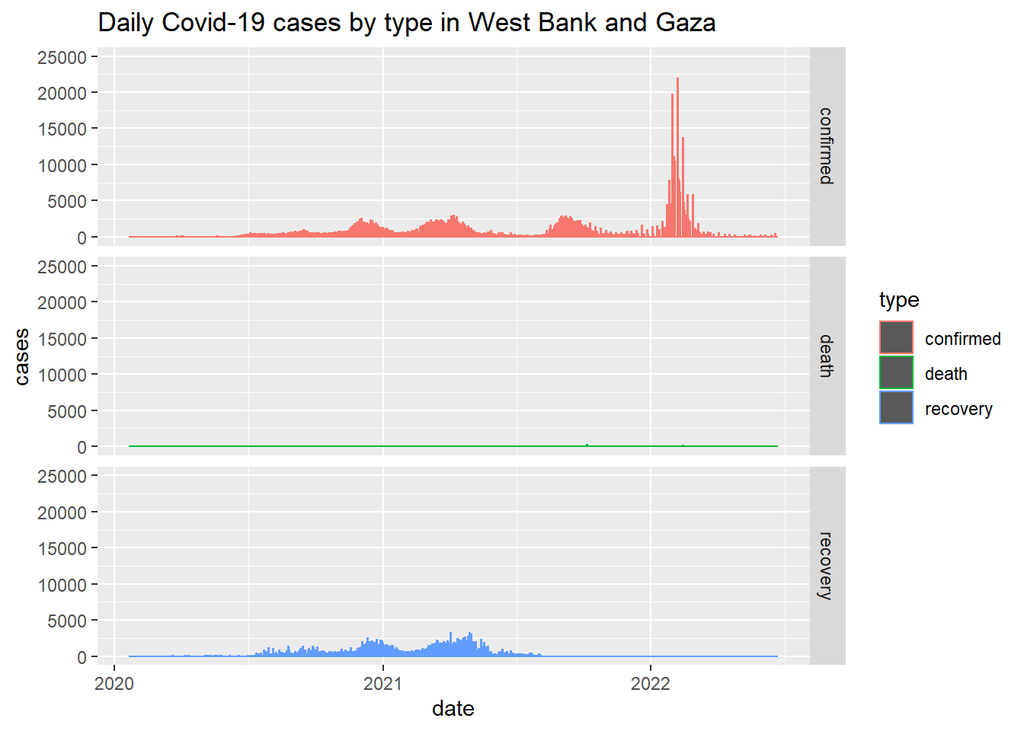

Figure 9

## Comparison with other countries

### **Israel, Jordan, Lebanon**

Comparison countries were choosen according to the geographical position. all the three countries situated in the same region.

- Israel : A Middle Eastern country on the Mediterranean Sea, is regarded by Jews, Christians and Muslims as the biblical Holy Land.
- Jordan : An Arab nation on the east bank of the Jordan River, is defined by ancient monuments, nature reserves and seaside resorts
- Lebanon : Is a country in Western Asia, located between Syria to the north and east and Israel to the south

### **Comparison of death cases by country over the time**

[figure not shown]

Figure 10

### **Comparison of recovered cases by country over the time**

[figure not shown]

Figure 11

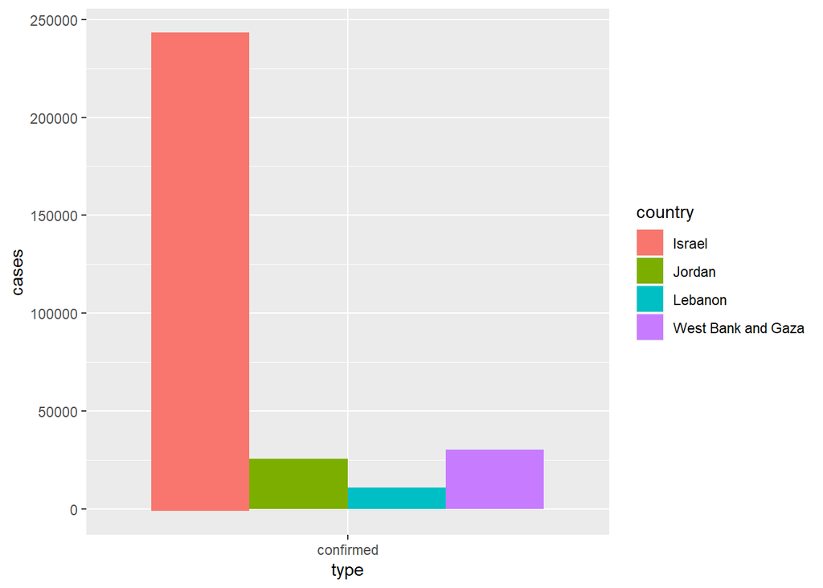

### **Reference**

- https://latitude.to/articles-by-country/ps/palestine/467/west-bank
- https://en.wikipedia.org/wiki/West_Bank
- https://en.wikipedia.org/wiki/Gaza_Strip
- http://www.emro.who.int/images/stories/palestine/documents/Palestine_Authority_COVID-19_Response_Plan_Final_26_3_2020.pdf?ua=1
- https://www.statology.org/multiple-histograms-r/
- https://coronavirus.jhu.edu/region/west-bank-and-gaza